# Final Q

## Raw French PT2

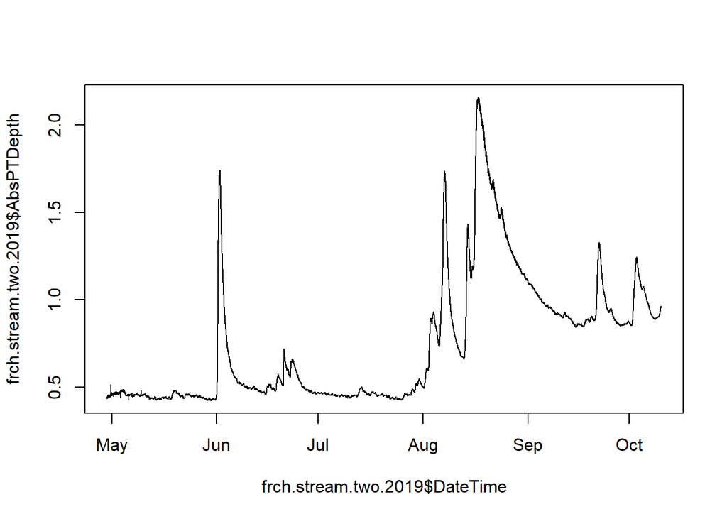

Going to clean some of the vertical bars in may but other than that this looks pretty good! let the cleaning commence

FRCH PT2 2.0

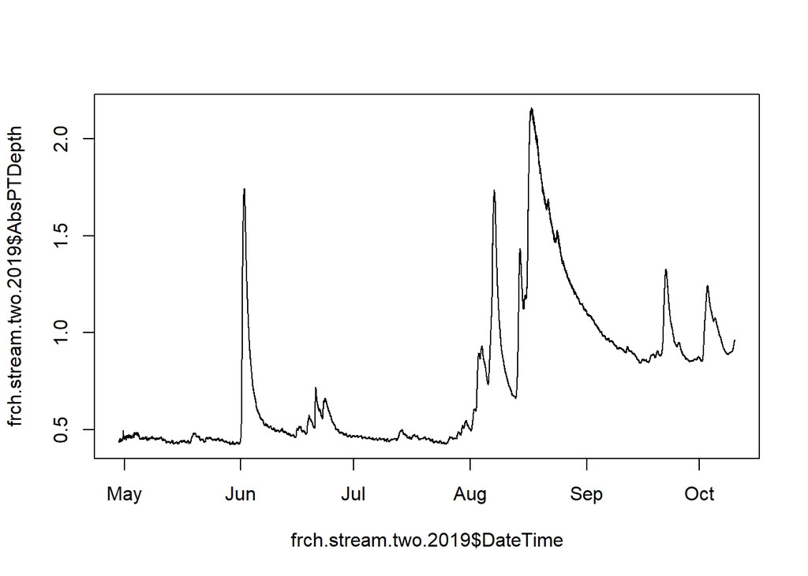

1) removed vertical bars early on in season

Check closeness between French PT1 and PT2

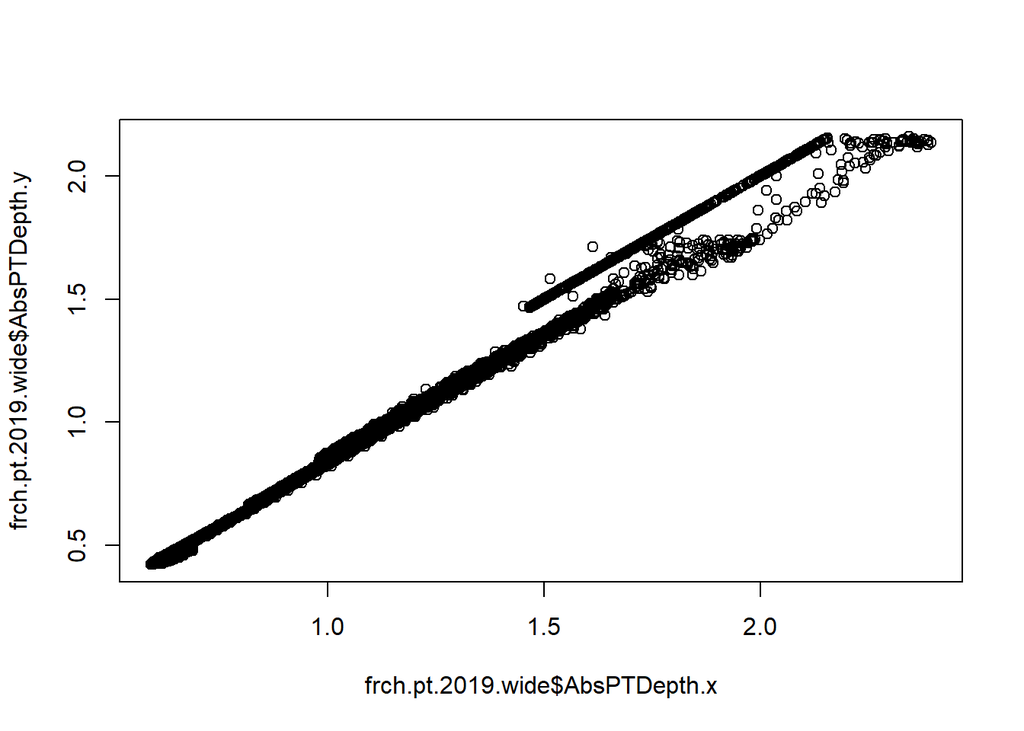

```r
frch.pt.2019.wide <- full_join(frch.stream.one.2019[,4:5], frch.stream.two.2019[,4:5], by = "DateTime")
plot(frch.pt.2019.wide$AbsPTDepth.x, frch.pt.2019.wide$AbsPTDepth.y)
```

Export PT data to csv to DoD_Discharge->PT_data->2019

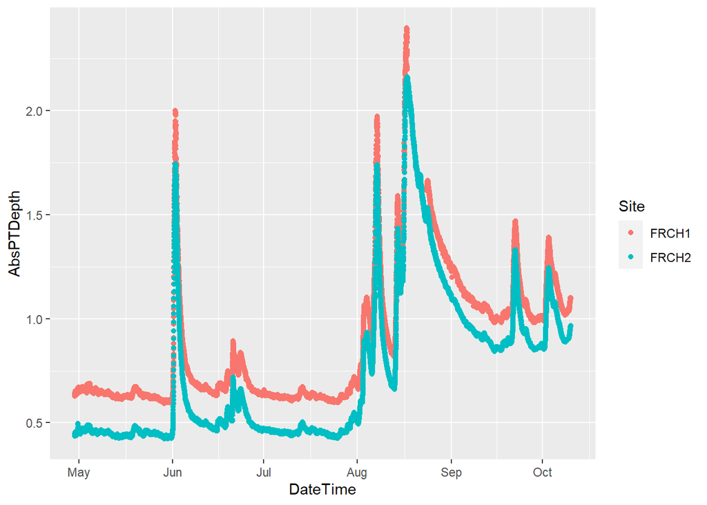

# Raw Rating Curve with French 1 Pressure Transducer

```
##
## Call:
## lm(formula = French1comb.2019$Q_Ls ~ French1comb.2019$AbsPTDepth)
##
## Residuals:
##     Min      1Q  Median      3Q     Max
## -371.71  -46.80  -13.33   25.72  749.71
##
## Coefficients:
##                             Estimate Std. Error t value Pr(>|t|)
## (Intercept)                  -1015.5      259.5  -3.914 0.002893 **
## French1comb.2019$AbsPTDepth   1860.6      320.8   5.800 0.000173 ***
## ---
## Signif. codes:  0 '***' 0.001 '**' 0.01 '*' 0.05 '.' 0.1 ' ' 1
##
## Residual standard error: 285.8 on 10 degrees of freedom
##   (15711 observations deleted due to missingness)
## Multiple R-squared:  0.7709, Adjusted R-squared:  0.748
## F-statistic: 33.64 on 1 and 10 DF,  p-value: 0.0001729
```

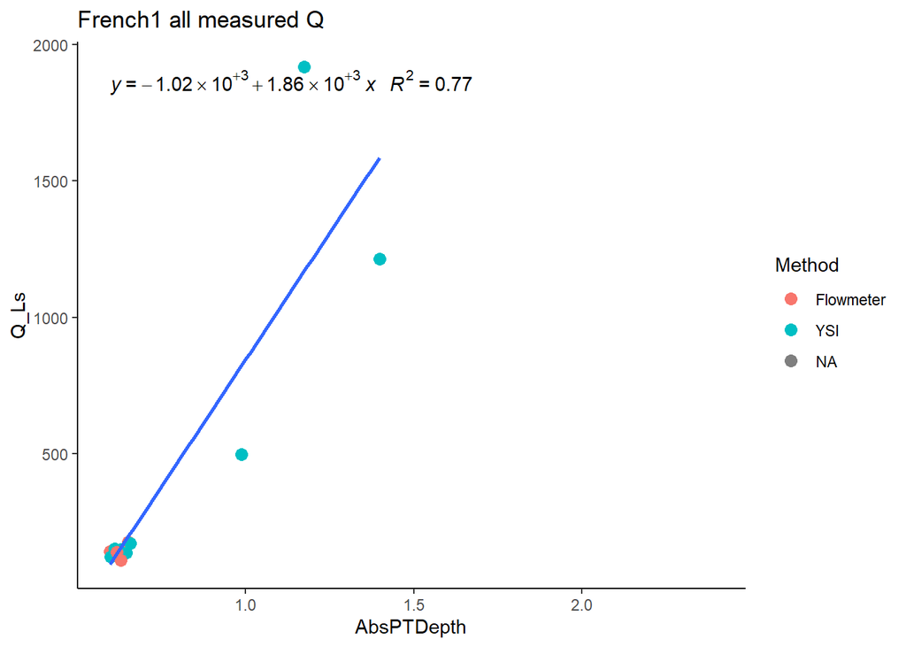

Lots of points that are clustered at the bottom. I will remove the 3 large YSI points

```
##
## Call:
## lm(formula = French2comb.2019$Q_Ls ~ French2comb.2019$AbsPTDepth)
##
## Residuals:
##     Min      1Q  Median      3Q     Max
## -36.779  -7.224   3.299  13.574  18.547
##
## Coefficients:
##                             Estimate Std. Error t value Pr(>|t|)
## (Intercept)                   -173.4      192.8  -0.899    0.398
## French2comb.2019$AbsPTDepth    507.9      307.4   1.652    0.142
##
## Residual standard error: 19.08 on 7 degrees of freedom
##   (15714 observations deleted due to missingness)
## Multiple R-squared:  0.2805, Adjusted R-squared:  0.1778
## F-statistic:  2.73 on 1 and 7 DF,  p-value: 0.1425
```

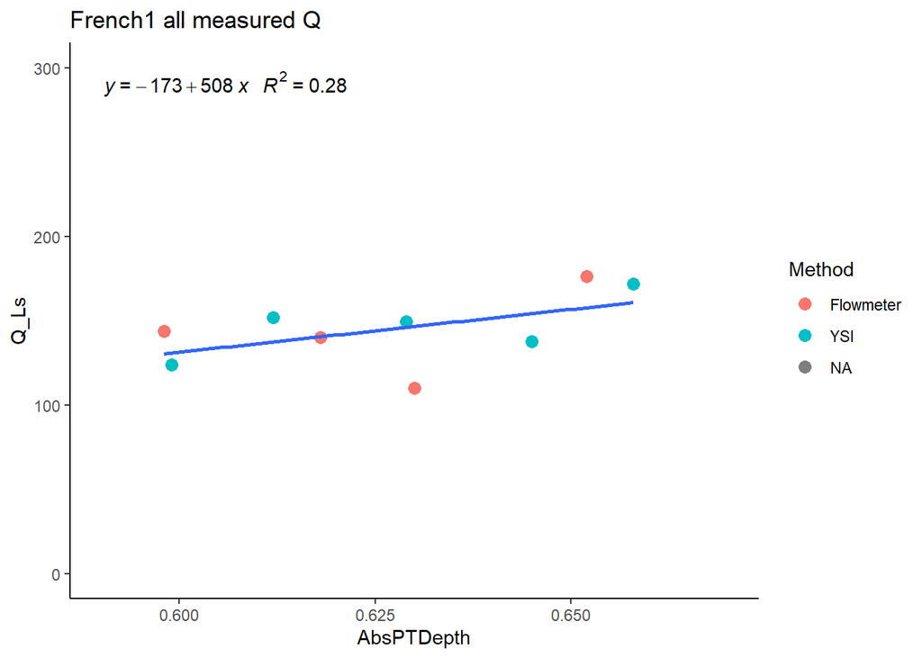

Not as good of an R^2.

Rating curve with two high Q points.

```
##
## Call:
## lm(formula = French1comb.2019$Q_Ls ~ French1comb.2019$AbsPTDepth)
##
## Residuals:
##      Min       1Q   Median       3Q      Max
## -117.849  -16.236    7.995   27.409   59.395
##
## Coefficients:
##                             Estimate Std. Error t value Pr(>|t|)
## (Intercept)                  -687.27      49.38  -13.92 2.16e-07 ***
## French1comb.2019$AbsPTDepth  1317.40      64.38   20.46 7.42e-09 ***
## ---
## Signif. codes:  0 '***' 0.001 '**' 0.01 '*' 0.05 '.' 0.1 ' ' 1
##
## Residual standard error: 50.41 on 9 degrees of freedom
##   (15712 observations deleted due to missingness)
## Multiple R-squared:  0.979,  Adjusted R-squared:  0.9766
## F-statistic: 418.7 on 1 and 9 DF,  p-value: 7.422e-09
```

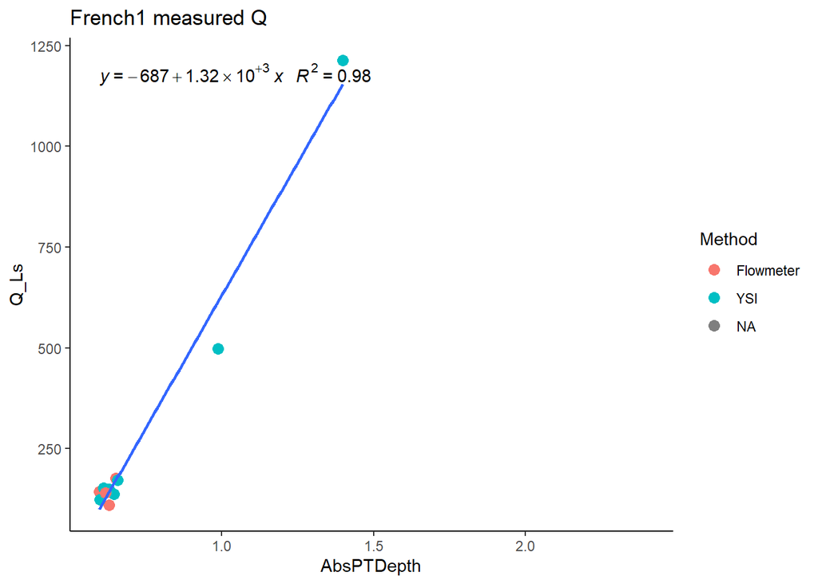

# Predict Q French1

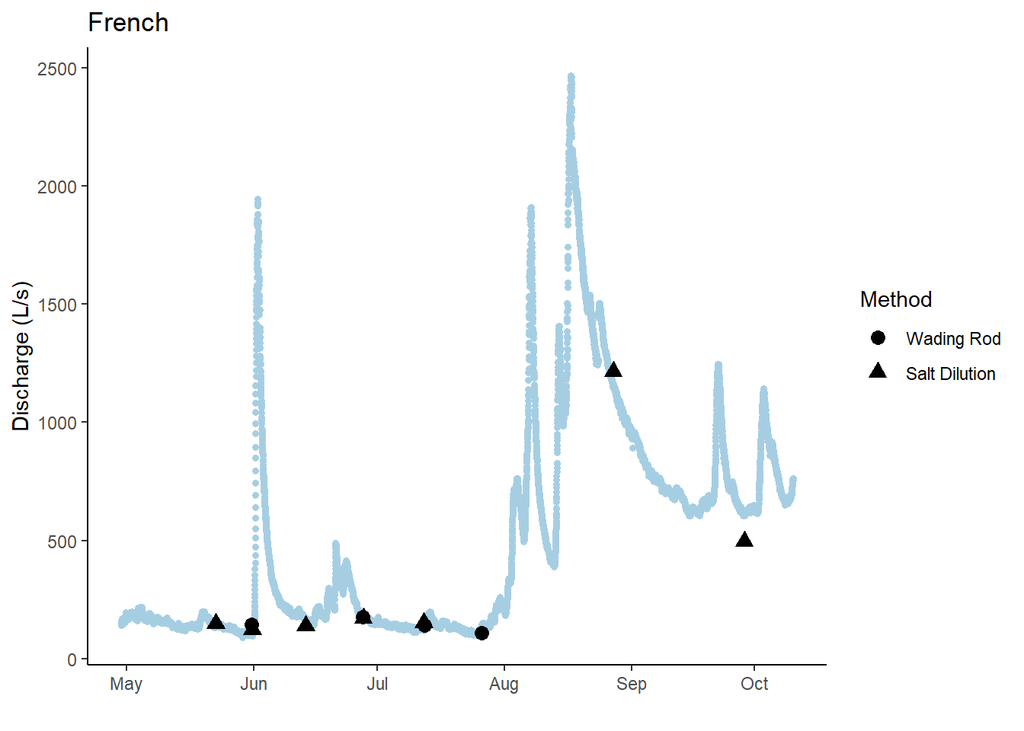

# Raw Rating Curve with French 2 Pressure Transducer

```
##
## Call:
## lm(formula = French3comb.2019$Q_Ls ~ French3comb.2019$AbsPTDepth)
##
## Residuals:
##     Min      1Q  Median      3Q     Max
## -140.69  -18.49   12.33   27.52   74.47
##
## Coefficients:
##                             Estimate Std. Error t value Pr(>|t|)
## (Intercept)                  -432.19      44.05  -9.812 4.19e-06 ***
## French3comb.2019$AbsPTDepth  1252.24      71.51  17.512 2.92e-08 ***
## ---
## Signif. codes:  0 '***' 0.001 '**' 0.01 '*' 0.05 '.' 0.1 ' ' 1
##
## Residual standard error: 58.68 on 9 degrees of freedom
##   (15709 observations deleted due to missingness)
## Multiple R-squared:  0.9715, Adjusted R-squared:  0.9683
## F-statistic: 306.7 on 1 and 9 DF,  p-value: 2.921e-08
```

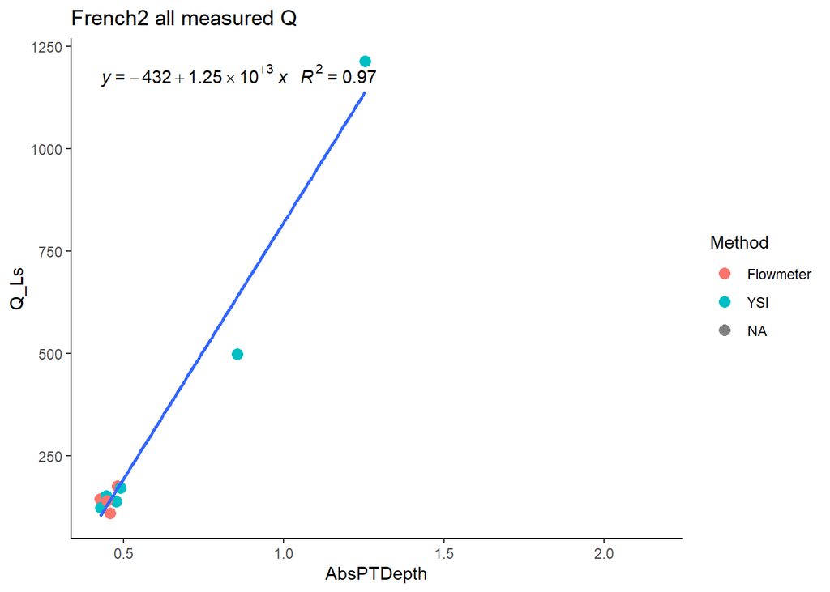

[output not shown]

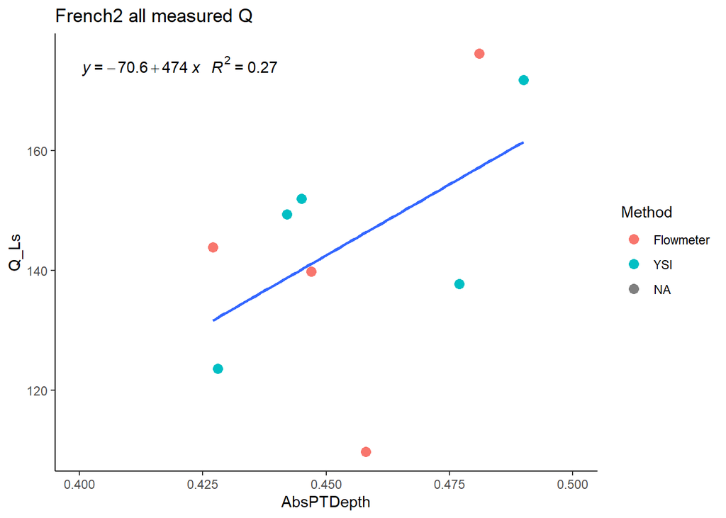

I will remove the low flowmeter point for the next plot

```
##
## Call:
## lm(formula = French5comb.2019$Q_Ls ~ French5comb.2019$AbsPTDepth)
##
## Residuals:
##     Min      1Q  Median      3Q     Max
## -22.839  -7.283   5.534   7.775  13.699
##
## Coefficients:
##                             Estimate Std. Error t value Pr(>|t|)
## (Intercept)                   -79.34      94.08  -0.843   0.4314
## French5comb.2019$AbsPTDepth   502.99     206.66   2.434   0.0509 .
## ---
## Signif. codes:  0 '***' 0.001 '**' 0.01 '*' 0.05 '.' 0.1 ' ' 1
##
## Residual standard error: 13.44 on 6 degrees of freedom
##   (15712 observations deleted due to missingness)
## Multiple R-squared:  0.4968, Adjusted R-squared:  0.4129
## F-statistic: 5.924 on 1 and 6 DF,  p-value: 0.0509
```

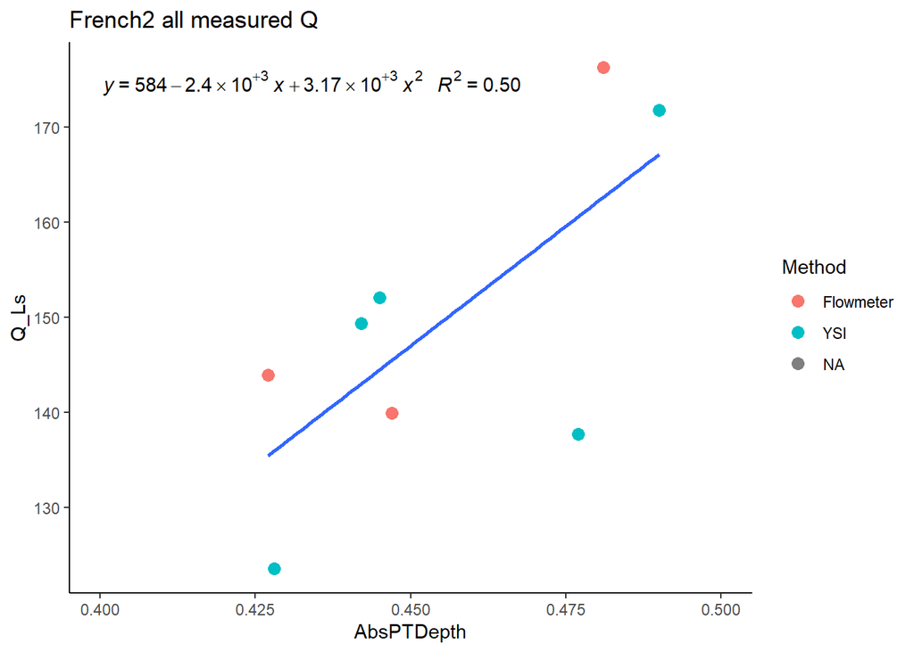

Lets also remove that high depth, low Q YSI point.

```
##
## Call:
## lm(formula = French6comb.2019$Q_Ls ~ French6comb.2019$AbsPTDepth)
##
## Residuals:
##    2208    3058    3069    5650    5664    7082    7098
##   4.628   9.098 -11.855   5.714  -4.740   5.310  -8.155
##
## Coefficients:
##                             Estimate Std. Error t value Pr(>|t|)
## (Intercept)                  -148.15      66.39  -2.232  0.07602 .
## French6comb.2019$AbsPTDepth   662.66     146.88   4.512  0.00633 **
## ---
## Signif. codes:  0 '***' 0.001 '**' 0.01 '*' 0.05 '.' 0.1 ' ' 1
##
## Residual standard error: 8.883 on 5 degrees of freedom
##   (15713 observations deleted due to missingness)
## Multiple R-squared:  0.8028, Adjusted R-squared:  0.7634
## F-statistic: 20.35 on 1 and 5 DF,  p-value: 0.006332
```

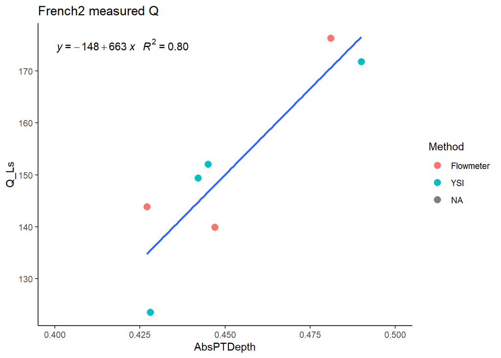

This is the RC I will use for predicted Q.

# Predicted Q FRCH PT2

Black points are observed Q

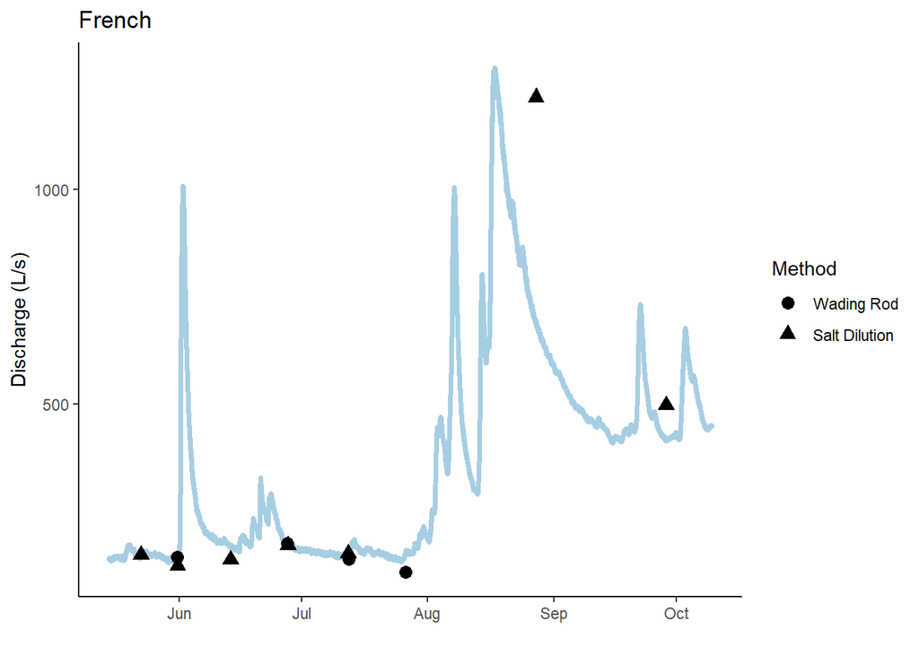

Without a big range in observed Q this is the best we can do.

Most of the water level is above the water level for our Q measurements. Maybe it is more accurate to include the high points?

```
##
## Call:
## lm(formula = French7comb.2019$Q_Ls ~ French7comb.2019$AbsPTDepth)
##
## Residuals:
##     Min      1Q  Median      3Q     Max
## -140.69  -18.49   12.33   27.52   74.47
##
## Coefficients:
##                             Estimate Std. Error t value Pr(>|t|)
## (Intercept)                  -432.19      44.05  -9.812 4.19e-06 ***
## French7comb.2019$AbsPTDepth  1252.24      71.51  17.512 2.92e-08 ***
## ---
## Signif. codes:  0 '***' 0.001 '**' 0.01 '*' 0.05 '.' 0.1 ' ' 1
##
## Residual standard error: 58.68 on 9 degrees of freedom
##   (15708 observations deleted due to missingness)
## Multiple R-squared:  0.9715, Adjusted R-squared:  0.9683
## F-statistic: 306.7 on 1 and 9 DF,  p-value: 2.921e-08
```

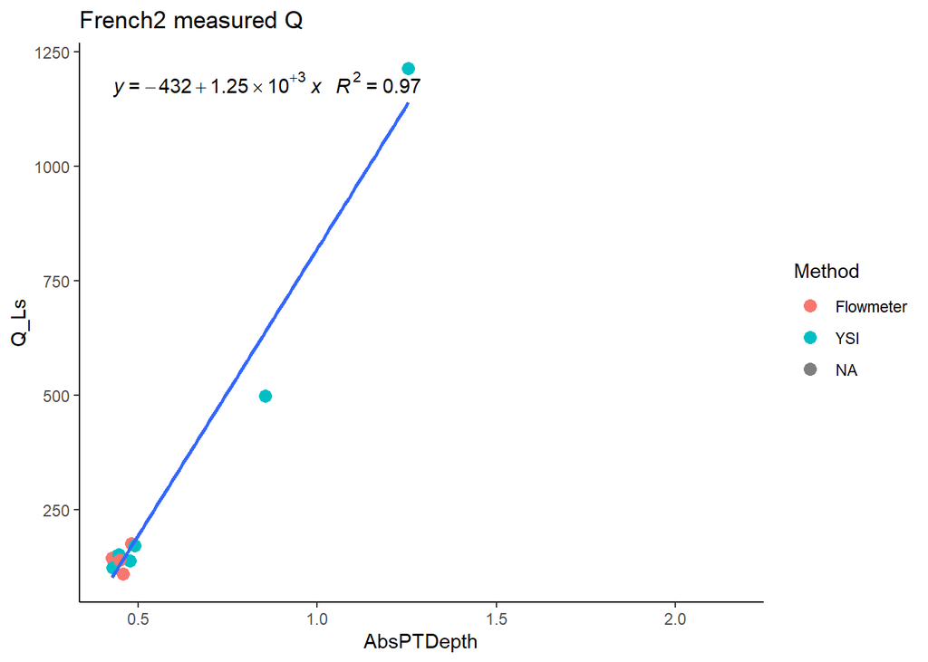

Lets plot and compare with previous prediction.

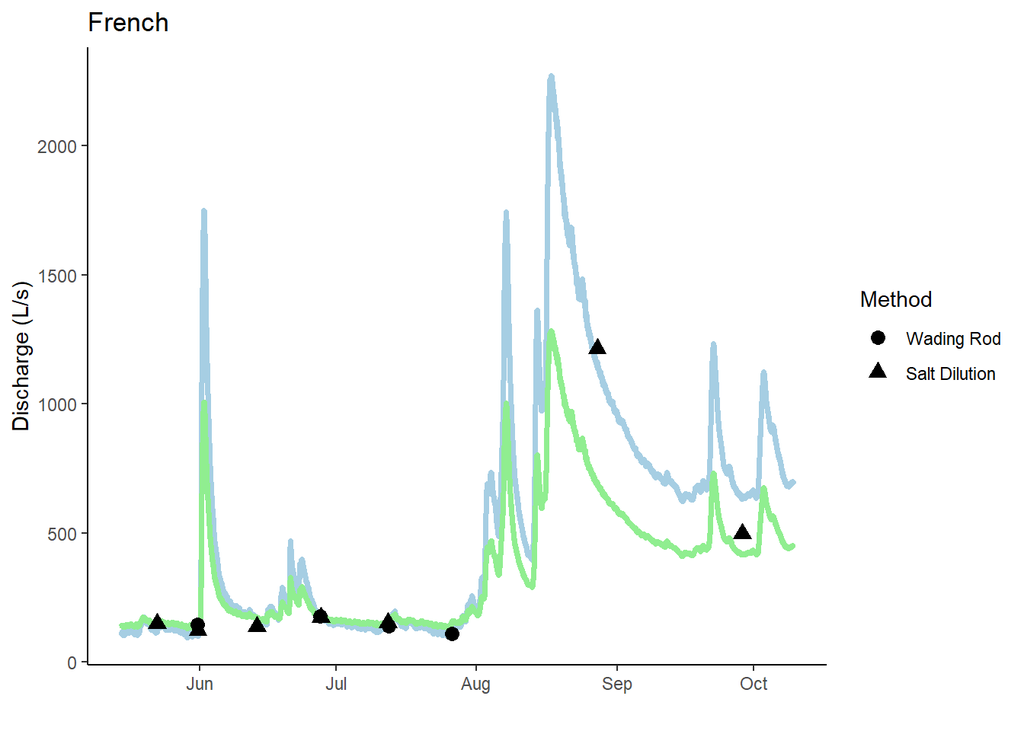

Lets zoom in on the low Q

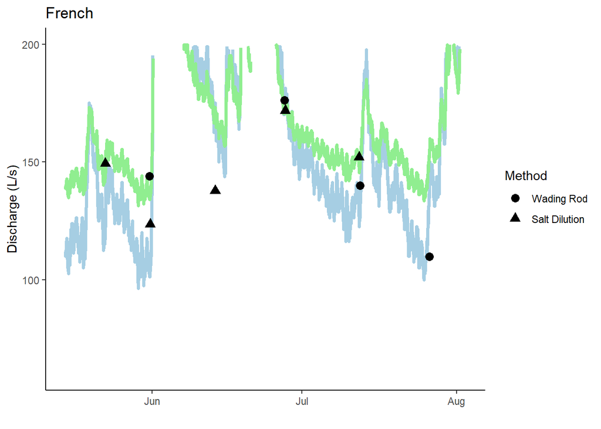

```r
p5 <- ggplot(aes(x = DateTime, y = pred.french2.Q), data=French7comb.2019) +
  geom_line(color="#A6CEE3", size=1.25) +
  geom_line(data = French6comb.2019, aes(DateTime, pred.french2.Q), color= "light green", size=1.25) +
  geom_point(data = French1comb.2019, aes(x = DateTime, y = Q_Ls, shape = Method), size=3) +
  theme_classic() +
  ggtitle("French") +
  scale_shape_discrete(name = "Method", labels = c("Wading Rod", "Salt Dilution", "")) +
  xlab("") +
  ylab("Discharge (L/s)") +
  ylim(60, 200) +
  scale_x_datetime(limits = as_datetime(c("2019-05-15", "2019-8-03")))

p5
```

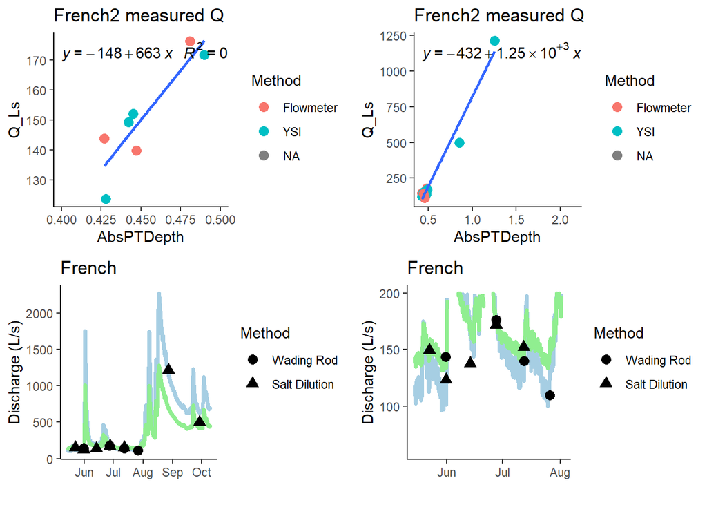

```r
library(gridExtra)
grid.arrange(p1, p3, p4, p5)
```

It looks to me (Karen) that the prediction using the regression including the two high Q points fits better. I will use this to predict discharge.

### Compare FRCH PT1 and PT2

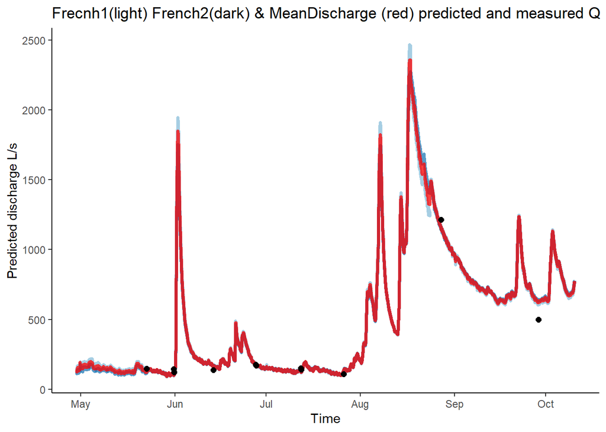

# Export PT data to csv to DoD_Discharge->Predicted_Discharge->2019

## Raw Poker PT1 2019

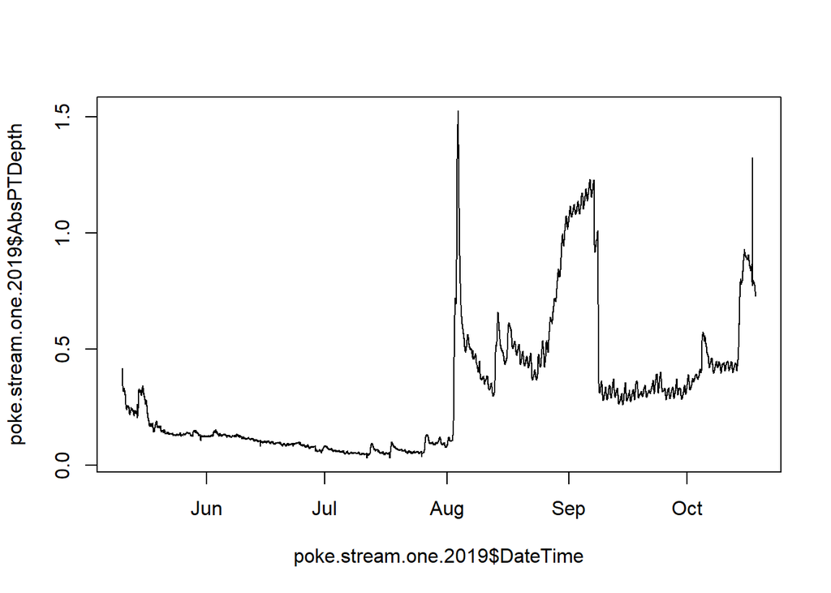

The beginning increase appears to be real with the precip on top. I need to remove some of the “vertical bars within the data frame and check take out date. I am also going to take out the beaver dam that is there from late august to middle of september Let the cleaning commence!

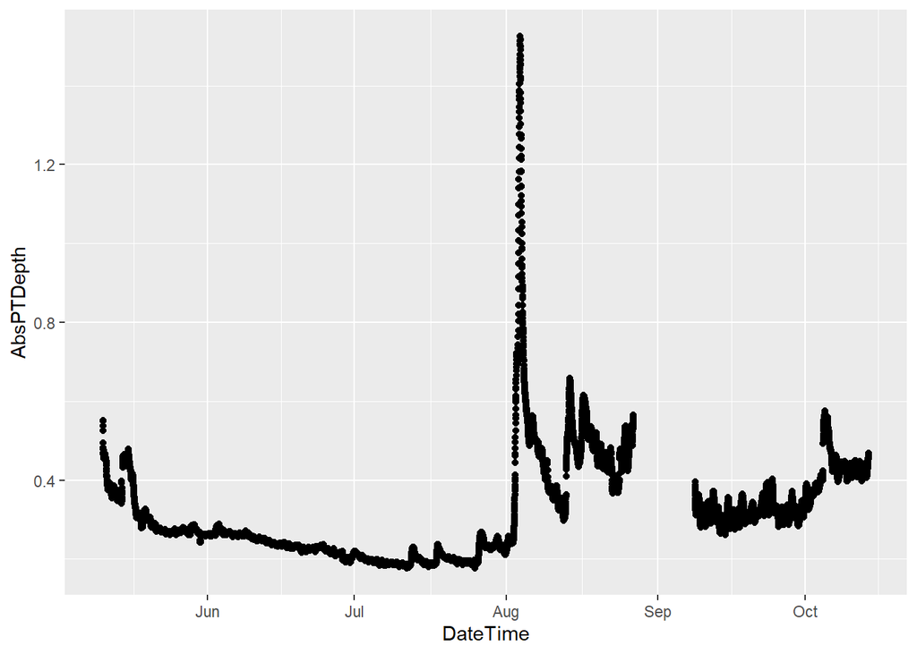

1) Removed vertical bars early on in dataset 2) Removed beaver dam related data entirely 3) removed end of season out of water points

## Raw Poker PT2

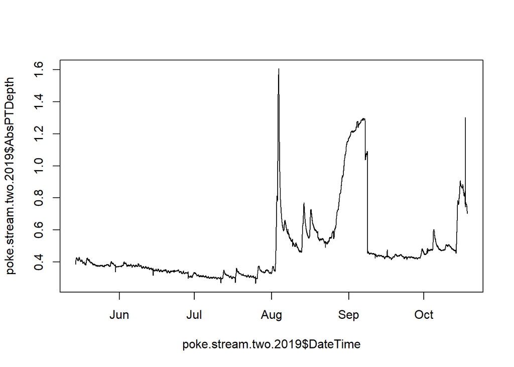

Same procedure as PT1….let the cleaning commence!

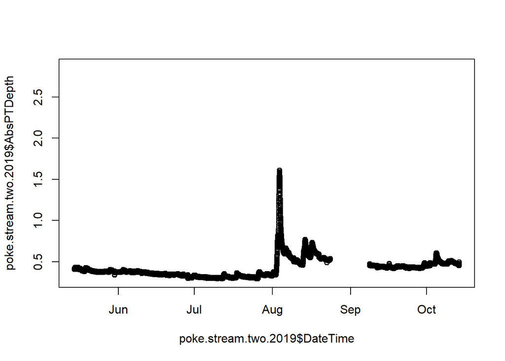

1) Removed vertical bars early on in dataset 2) Removed beaver dam related data entirely 3) removed end of season out of water points

### export PT data to csv to DoD_Discharge->PT_data->2019

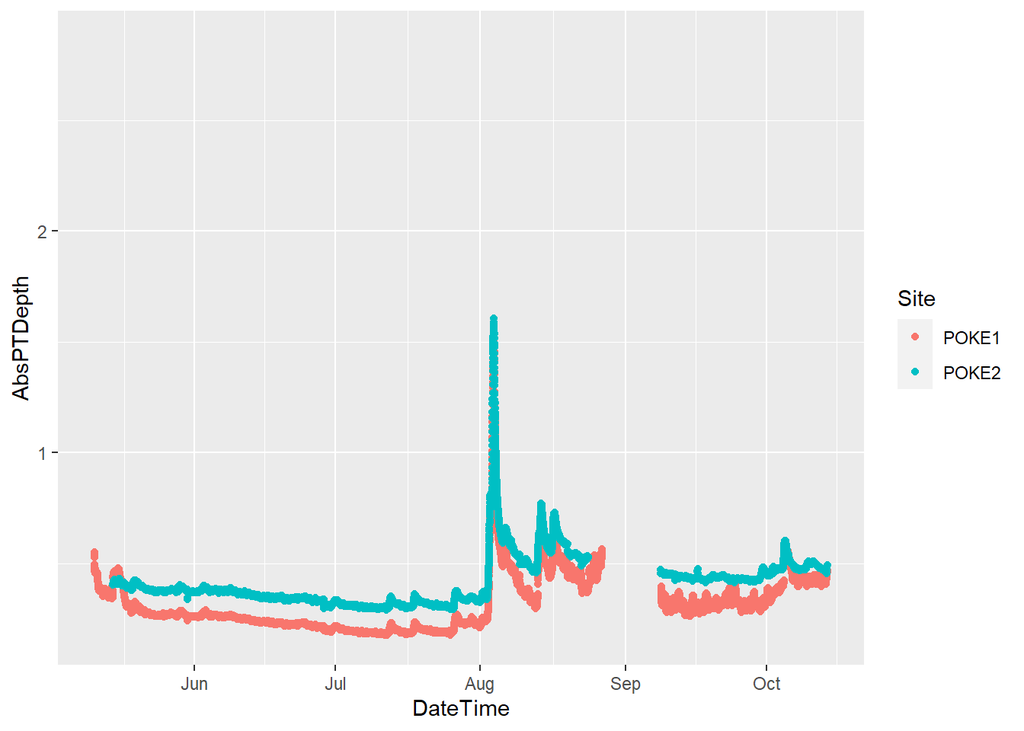

### Raw Rating Curve with Poker 1 Pressure Transducer

```
##
## Call:
## lm(formula = Poker1comb.2019$Q_Ls ~ Poker1comb.2019$AbsPTDepth)
##
## Residuals:
##     Min      1Q  Median      3Q     Max
## -117.02  -72.84  -10.91   30.54  234.72
##
## Coefficients:
##                             Estimate Std. Error t value Pr(>|t|)
## (Intercept)                3.411e-02  1.130e+02   0.000   0.9998
## Poker1comb.2019$AbsPTDepth 1.234e+03  3.853e+02   3.204   0.0125 *
## ---
## Signif. codes:  0 '***' 0.001 '**' 0.01 '*' 0.05 '.' 0.1 ' ' 1
##
## Residual standard error: 112 on 8 degrees of freedom
##   (13799 observations deleted due to missingness)
## Multiple R-squared:  0.562,  Adjusted R-squared:  0.5072
## F-statistic: 10.26 on 1 and 8 DF,  p-value: 0.01254
```

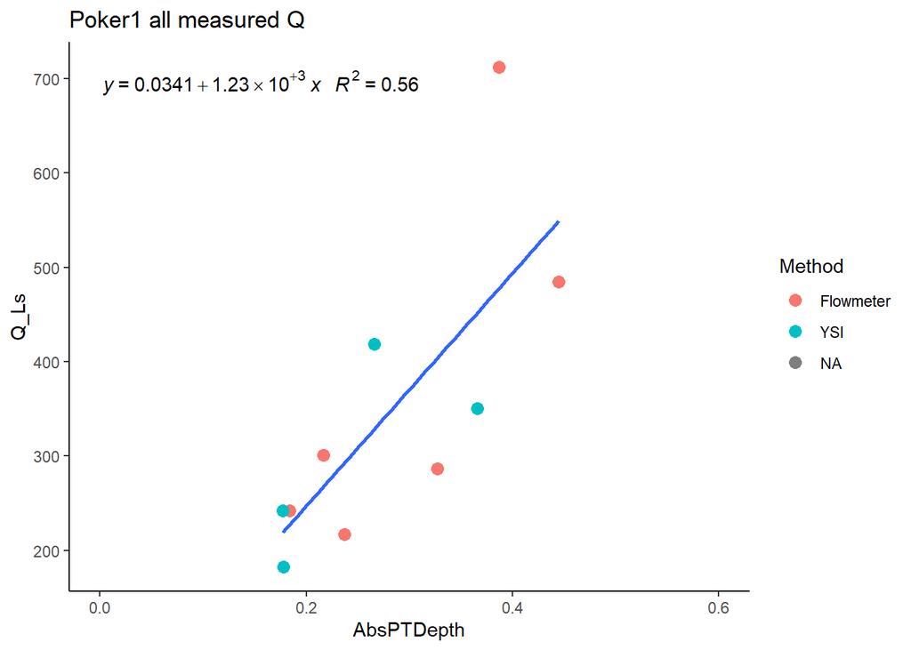

### Predicted Q POKE PT1

#### Black points are observed Q

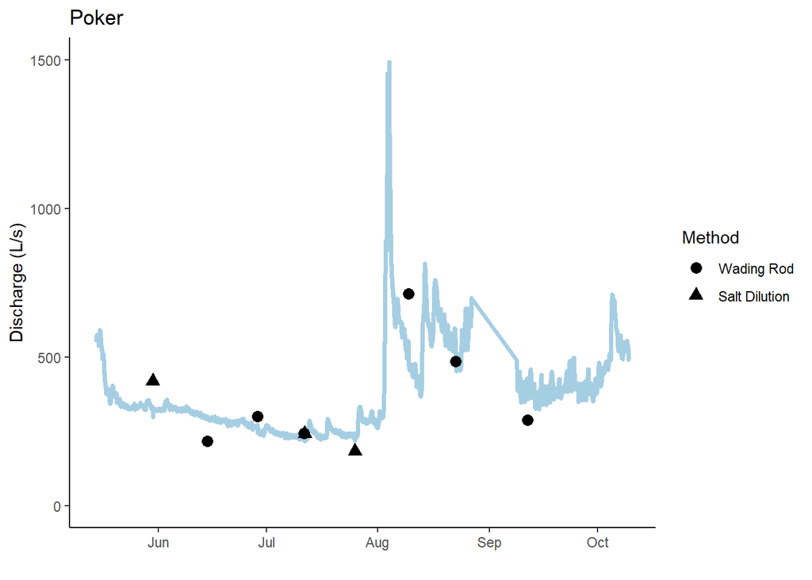

Not the worst thing I’ve seen in the world

### Raw Rating Curve with Poker 2 Pressure Transducer

```
##
## Call:
## lm(formula = Poker2comb.2019$Q_Ls ~ Poker2comb.2019$AbsPTDepth)
##
## Residuals:
##     Min      1Q  Median      3Q     Max
## -128.21  -78.42   28.37   31.08  168.99
##
## Coefficients:
##                            Estimate Std. Error t value Pr(>|t|)
## (Intercept)                  -285.8      160.2  -1.784  0.11759
## Poker2comb.2019$AbsPTDepth   1648.8      410.9   4.012  0.00511 **
## ---
## Signif. codes:  0 '***' 0.001 '**' 0.01 '*' 0.05 '.' 0.1 ' ' 1
##
## Residual standard error: 99.57 on 7 degrees of freedom
##   (13517 observations deleted due to missingness)
## Multiple R-squared:  0.697,  Adjusted R-squared:  0.6537
## F-statistic:  16.1 on 1 and 7 DF,  p-value: 0.005109
```

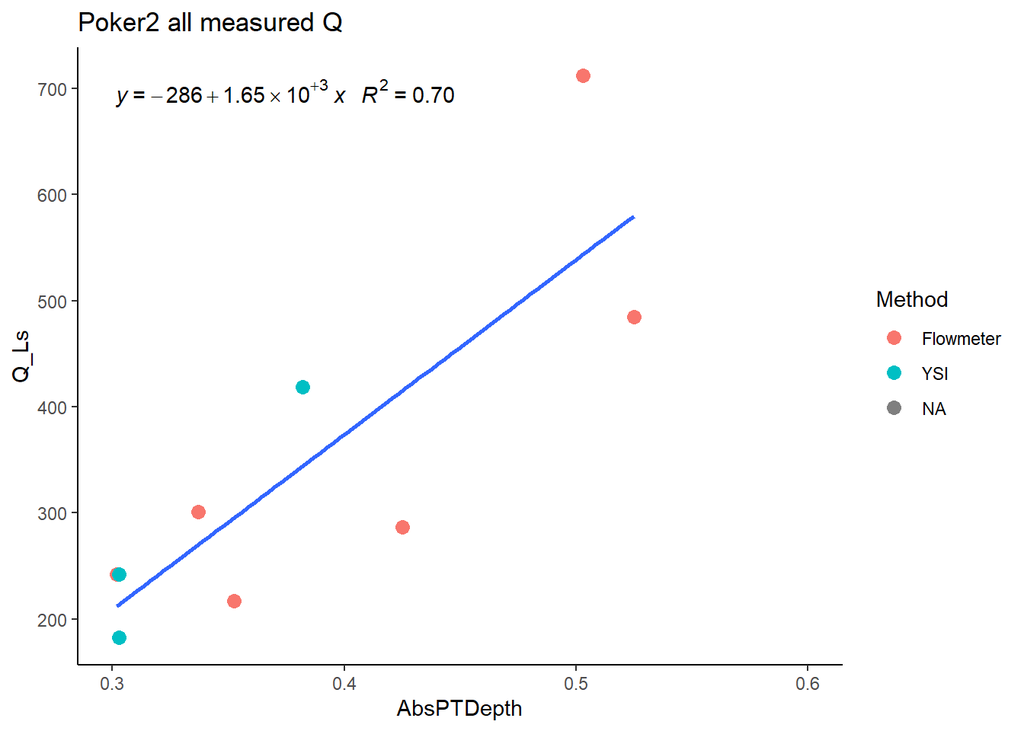

### Predicted Q POKE PT2 #### Black points are observed Q

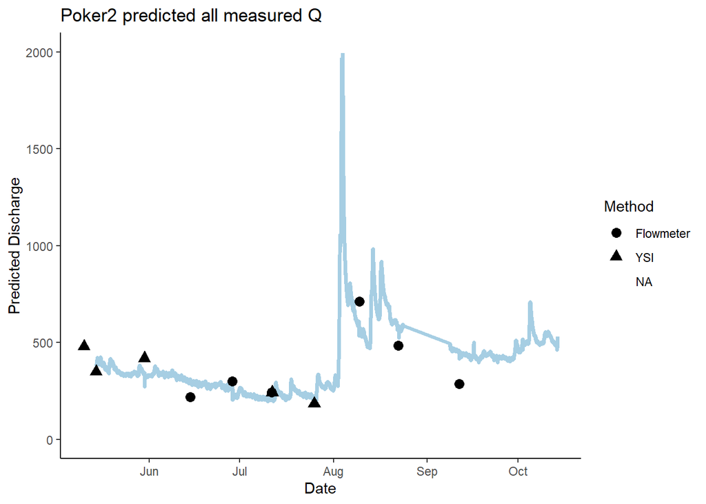

### Average POKE Q

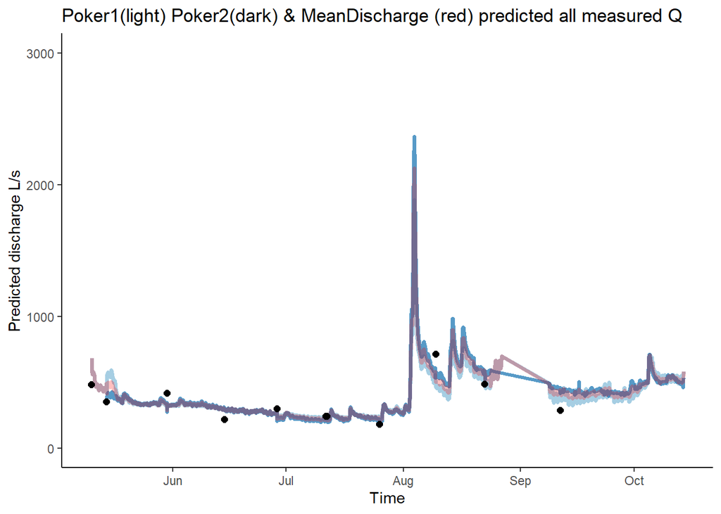

### export PT data to csv to DoD_Discharge->Predicted_Discharge->2019

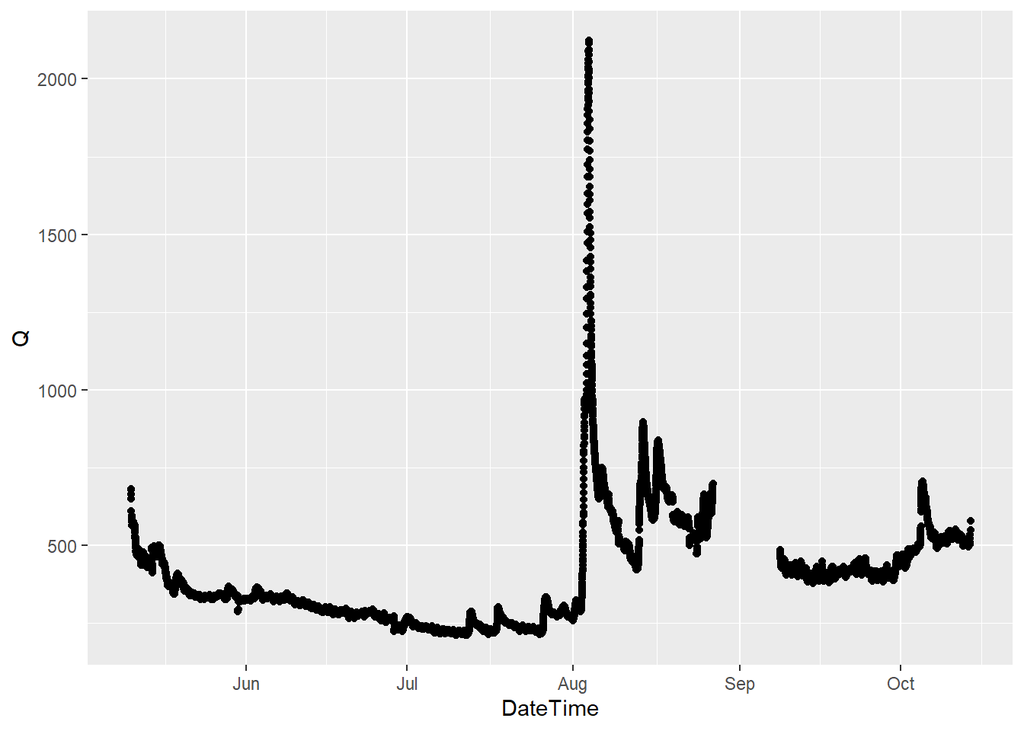

## Raw Vault PT1

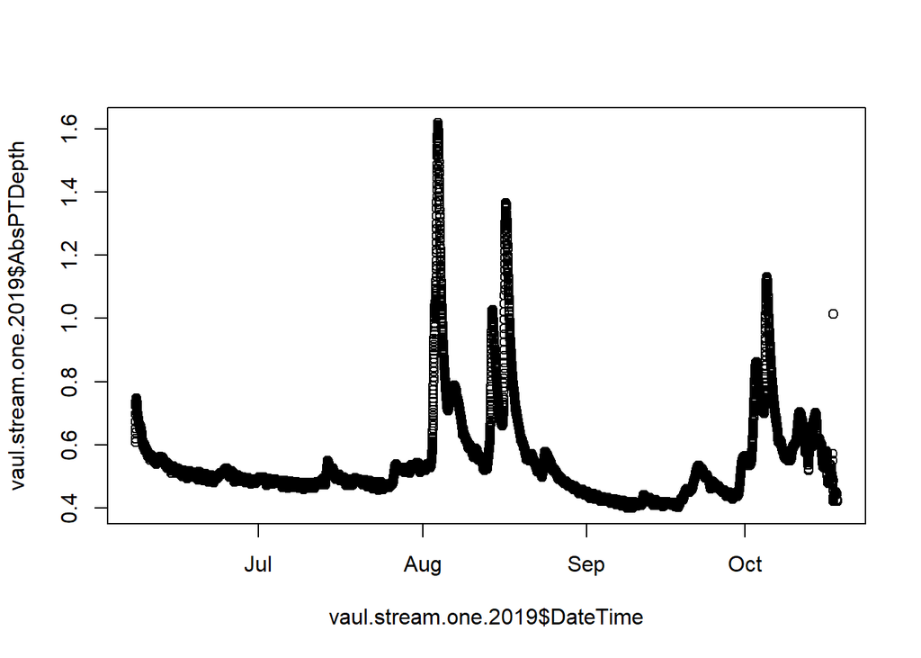

Out of water at the end of the year? Let the cleaning commence!

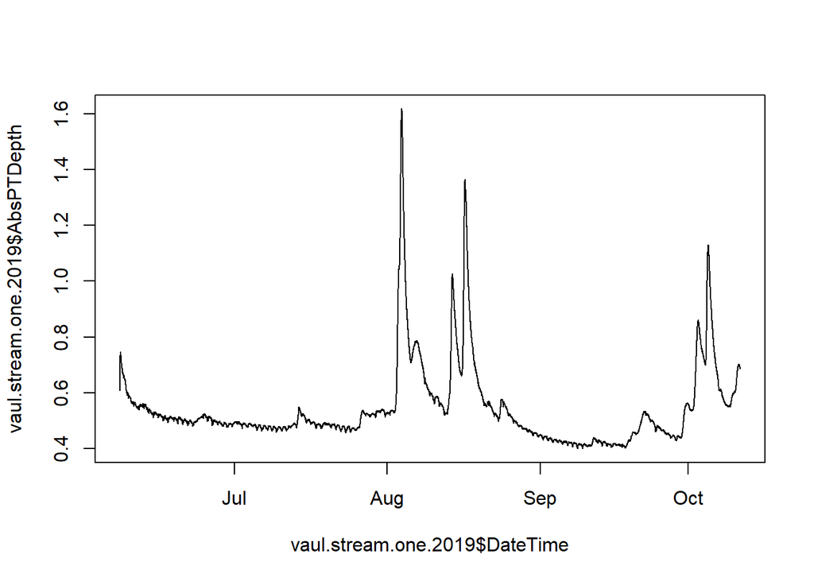

1) Removed end of record as there were erroneous points that might have been from ice on and then also out of water points

### export PT data to csv to DoD_Discharge->PT_data->2019

### Raw Rating Curve with VAUL PT1

```
##
## Call:
## lm(formula = Vaultcomb.2019$Q_Ls ~ 0 + Vaultcomb.2019$AbsPTDepth)
##
## Residuals:
##    Min     1Q Median     3Q    Max
## -86.91 -76.88 -41.14  54.53 169.09
##
## Coefficients:
##                           Estimate Std. Error t value Pr(>|t|)
## Vaultcomb.2019$AbsPTDepth   200.67      58.77   3.415  0.00769 **
## ---
## Signif. codes:  0 '***' 0.001 '**' 0.01 '*' 0.05 '.' 0.1 ' ' 1
##
## Residual standard error: 94.22 on 9 degrees of freedom
##   (12073 observations deleted due to missingness)
## Multiple R-squared:  0.5644, Adjusted R-squared:  0.516
## F-statistic: 11.66 on 1 and 9 DF,  p-value: 0.007692
```

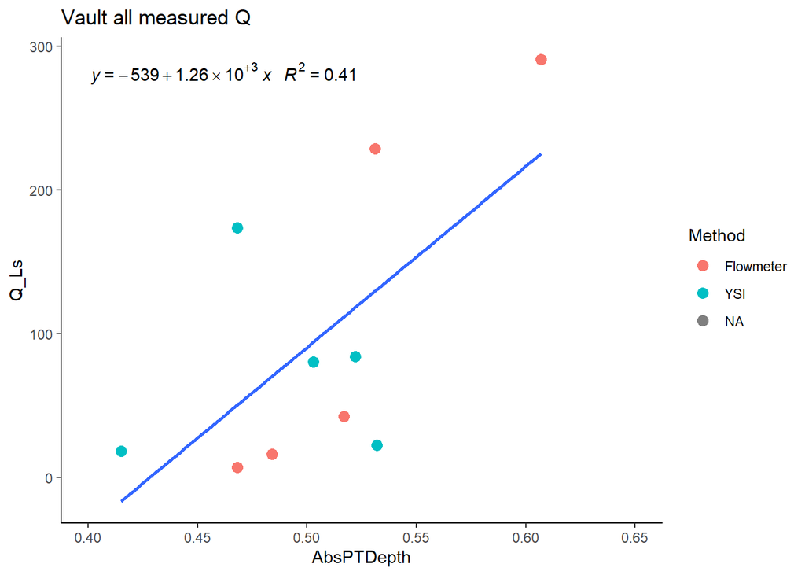

Lets remove the high YSI point and make it quadratic.

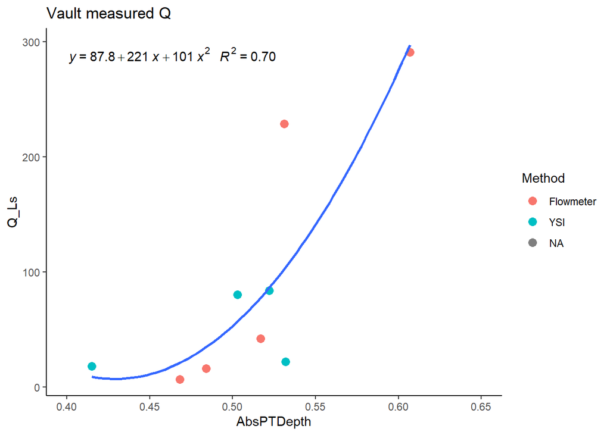

### Predicted Q VAULPT1 #### Black points are observed Q

```
##
## Call:
## lm(formula = Vaultcomb.2019.2$Q_Ls ~ Vaultcomb.2019.2$AbsPTDepth +
##     I(Vaultcomb.2019.2$AbsPTDepth^2))
##
## Residuals:
##     Min      1Q  Median      3Q     Max
## -81.893 -18.474  -6.369   9.091 126.314
##
## Coefficients:
##                                  Estimate Std. Error t value Pr(>|t|)
## (Intercept)                          1699       1540   1.103    0.312
## Vaultcomb.2019.2$AbsPTDepth         -7881       6047  -1.303    0.240
## I(Vaultcomb.2019.2$AbsPTDepth^2)     9180       5910   1.553    0.171
##
## Residual standard error: 64.74 on 6 degrees of freedom
##   (12072 observations deleted due to missingness)
## Multiple R-squared:  0.7006, Adjusted R-squared:  0.6008
## F-statistic:  7.02 on 2 and 6 DF,  p-value: 0.02684
```

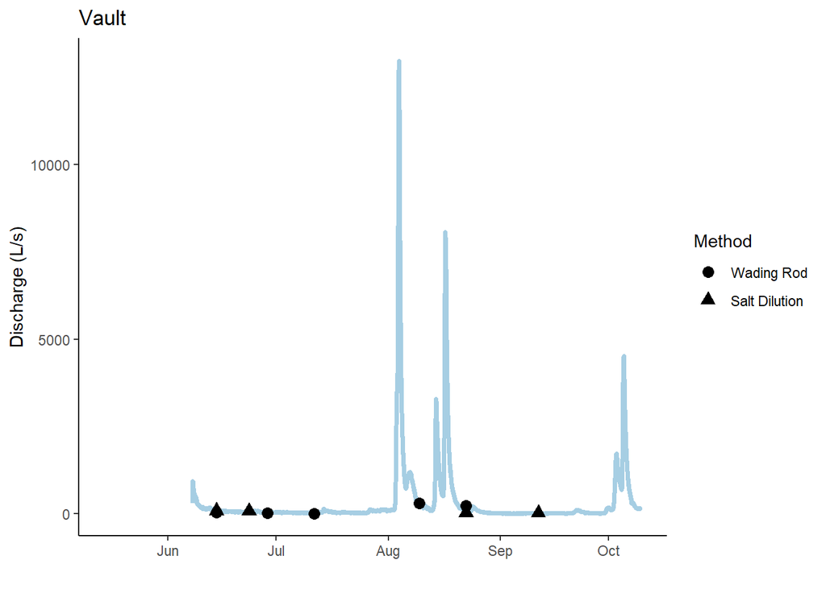

### export PT data to csv to DoD_Discharge->Predicted_Discharge->2019

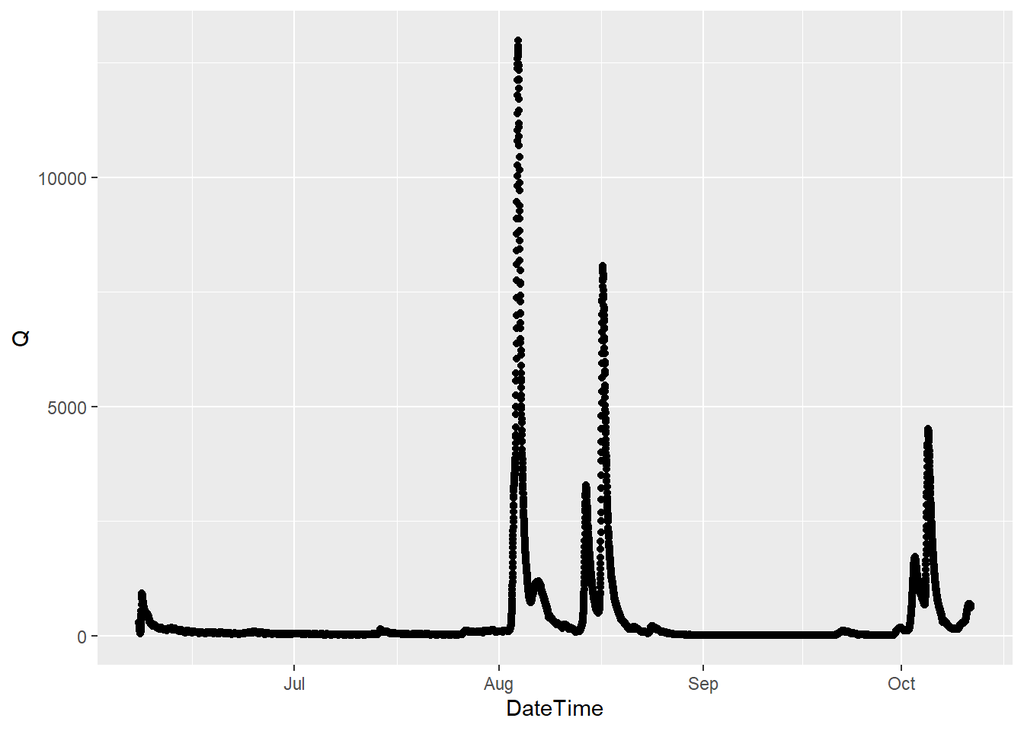

## Raw Stuart PT1

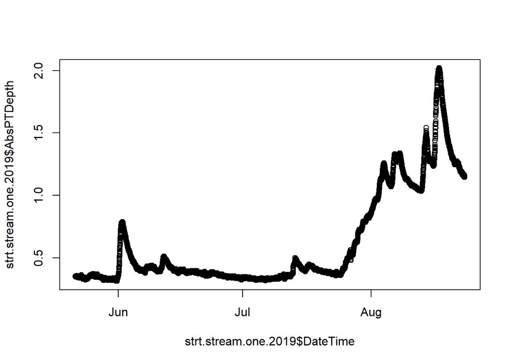

Stuart PT1 only has record until 8/23… Looks pretty clean though

## Raw Stuart PT2

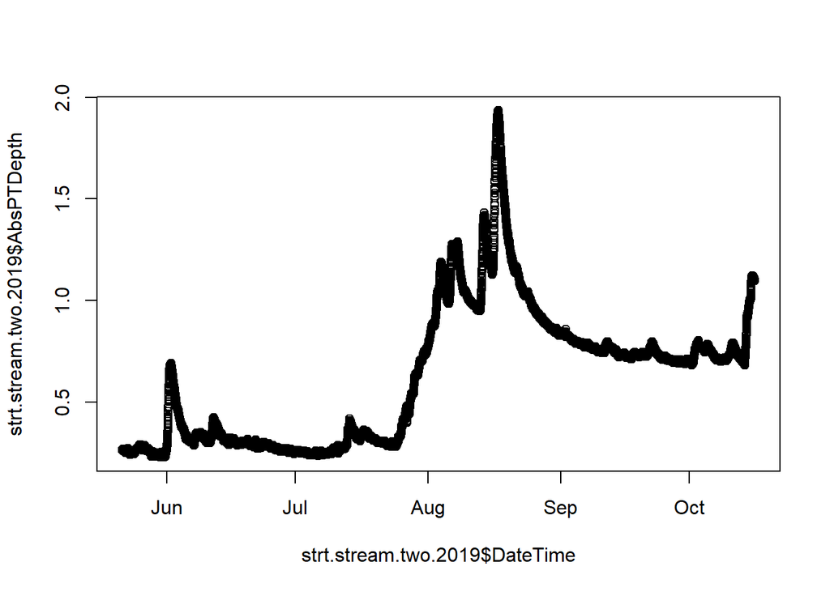

Just looks like I need to clip out the end of the season points there…Let the cleaning commence!

### STRT PT2 2.0

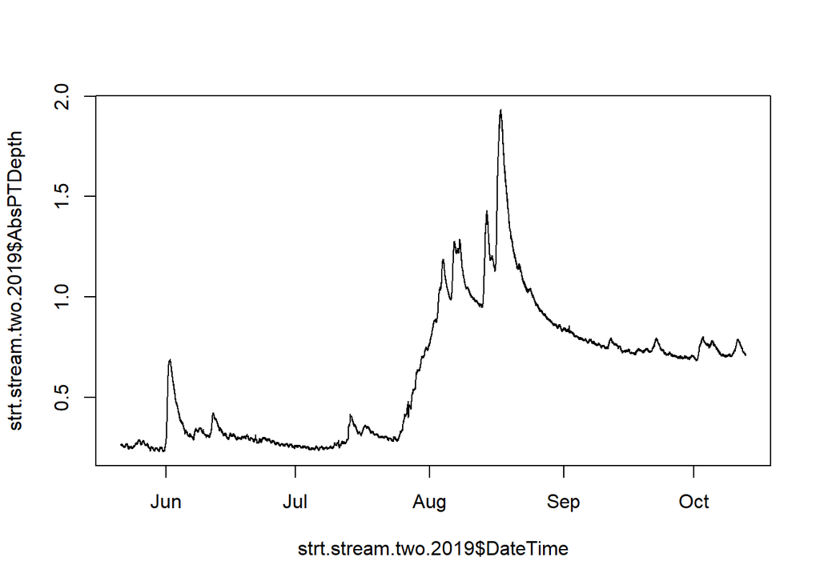

1) removed out of water points at the end of the season

### export PT data to csv to DoD_Discharge->PT_data->2019

### Raw Rating Curve with STRT PT1

```
##
## Call:
## lm(formula = Stuart1comb.2019$Q_Ls ~ Stuart1comb.2019$AbsPTDepth)
##
## Residuals:
##    1426    1428    2776    3447    3452    7478    8246
## -632.66 -181.02   85.74 -141.83  810.31 -117.82  177.28
##
## Coefficients:
##                             Estimate Std. Error t value Pr(>|t|)
## (Intercept)                   -732.6      339.8  -2.156 0.083610 .
## Stuart1comb.2019$AbsPTDepth   3823.0      446.1   8.570 0.000356 ***
## ---
## Signif. codes:  0 '***' 0.001 '**' 0.01 '*' 0.05 '.' 0.1 ' ' 1
##
## Residual standard error: 482.2 on 5 degrees of freedom
##   (9018 observations deleted due to missingness)
## Multiple R-squared:  0.9363, Adjusted R-squared:  0.9235
## F-statistic: 73.45 on 1 and 5 DF,  p-value: 0.0003564
```

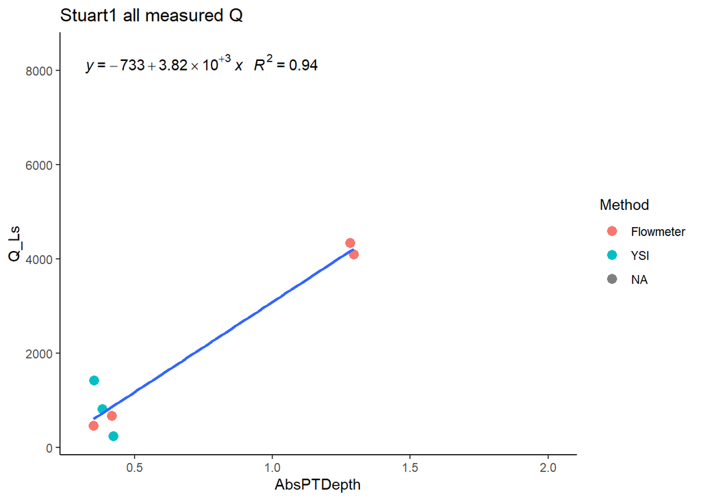

I think the first time I did this RC we took out the two large Flowmeter calculations but then that gives us a negative relationship which makes the predicted Q really bad

### Raw Rating Curve with STRT PT2

```
##
## Call:
## lm(formula = Stuart2comb.2019$Q_Ls ~ Stuart2comb.2019$AbsPTDepth)
##
## Residuals:
##     Min      1Q  Median      3Q     Max
## -1901.7 -1326.8  -797.3   168.5  4578.9
##
## Coefficients:
##                             Estimate Std. Error t value Pr(>|t|)
## (Intercept)                   -54.74    1419.13  -0.039   0.9703
## Stuart2comb.2019$AbsPTDepth  4905.18    1993.72   2.460   0.0434 *
## ---
## Signif. codes:  0 '***' 0.001 '**' 0.01 '*' 0.05 '.' 0.1 ' ' 1
##
## Residual standard error: 2249 on 7 degrees of freedom
##   (13854 observations deleted due to missingness)
## Multiple R-squared:  0.4637, Adjusted R-squared:  0.3871
## F-statistic: 6.053 on 1 and 7 DF,  p-value: 0.04345
```

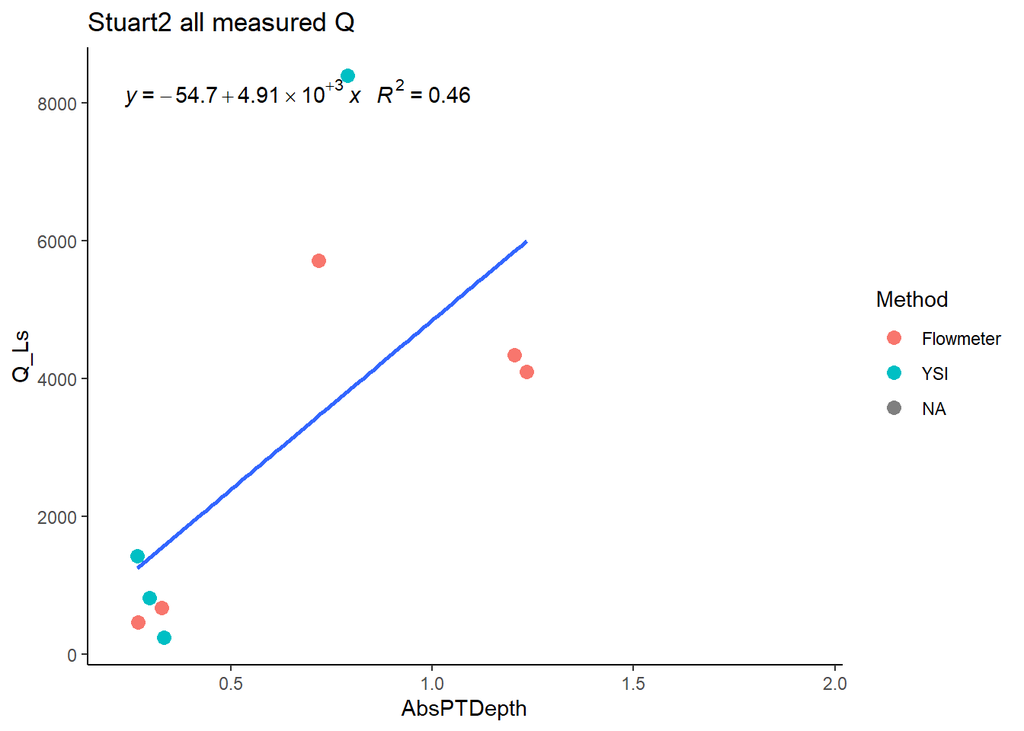

I am going to remove the high YSI pointt

### Rating Curve with STRT PT2 2.0

```
##
## Call:
## lm(formula = Stuart3comb.2019$Q_Ls ~ Stuart3comb.2019$AbsPTDepth)
##
## Residuals:
##     Min      1Q  Median      3Q     Max
## -946.69 -581.71 -458.34  -50.03 2922.95
##
## Coefficients:
##                             Estimate Std. Error t value Pr(>|t|)
## (Intercept)                   -176.8      858.4  -0.206    0.844
## Stuart3comb.2019$AbsPTDepth   4130.2     1223.8   3.375    0.015 *
## ---
## Signif. codes:  0 '***' 0.001 '**' 0.01 '*' 0.05 '.' 0.1 ' ' 1
##
## Residual standard error: 1360 on 6 degrees of freedom
##   (13855 observations deleted due to missingness)
## Multiple R-squared:  0.655,  Adjusted R-squared:  0.5975
## F-statistic: 11.39 on 1 and 6 DF,  p-value: 0.01495
```

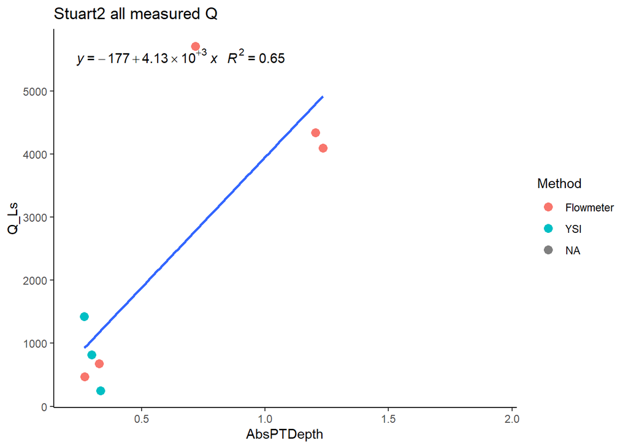

Ill remove the high flowmeter

### Rating Curve with STRT PT2 2.0

```
##
## Call:
## lm(formula = Stuart4comb.2019$Q_Ls ~ Stuart4comb.2019$AbsPTDepth)
##
## Residuals:
##   1426   1428   2776   3447   3452   7478   8246
## -615.3 -171.7   85.3 -159.5  804.0 -152.3  209.5
##
## Coefficients:
##                             Estimate Std. Error t value Pr(>|t|)
## (Intercept)                   -382.6      305.0  -1.255  0.26509
## Stuart4comb.2019$AbsPTDepth   3753.2      436.3   8.603  0.00035 ***
## ---
## Signif. codes:  0 '***' 0.001 '**' 0.01 '*' 0.05 '.' 0.1 ' ' 1
##
## Residual standard error: 480.5 on 5 degrees of freedom
##   (13856 observations deleted due to missingness)
## Multiple R-squared:  0.9367, Adjusted R-squared:  0.9241
## F-statistic: 74.01 on 1 and 5 DF,  p-value: 0.0003501
```

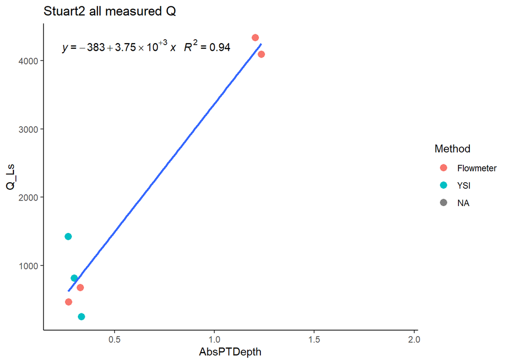

1)Removed top flowmeter and YSI point

### Predicted Q STRT PT1

#### Black points are observed Q

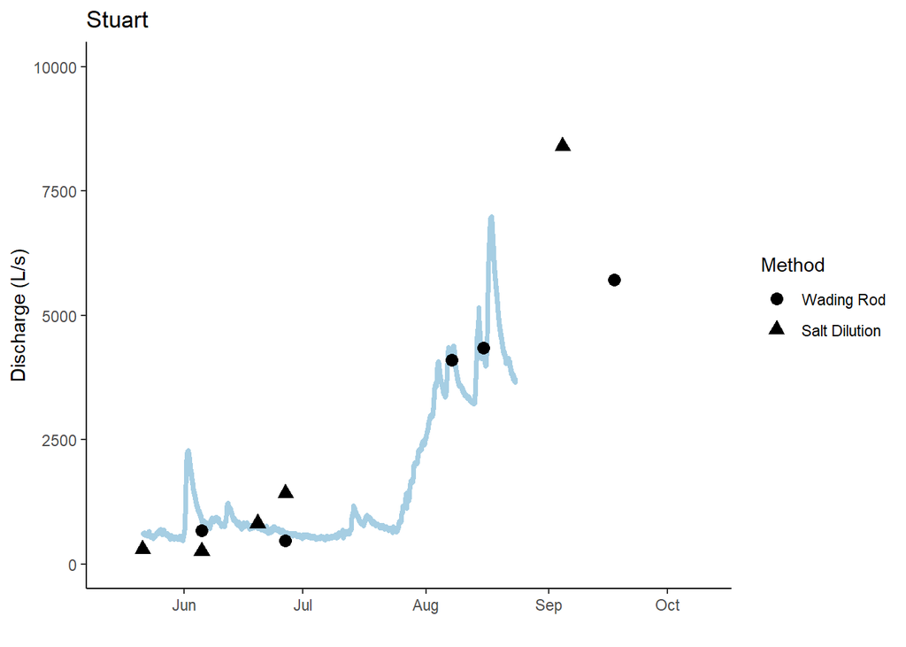

### Predicted Q STRT PT2

#### Black points are observed Q

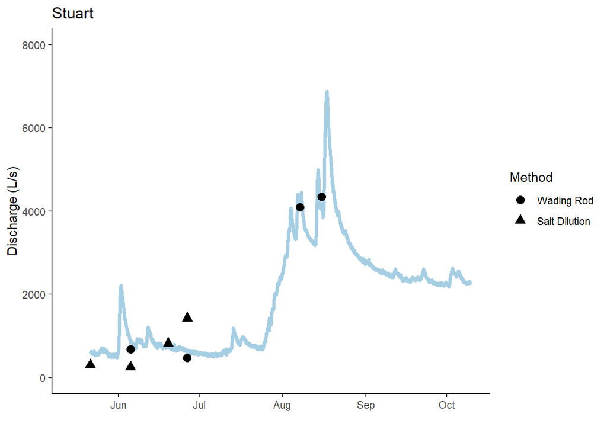

### Average STRT Q

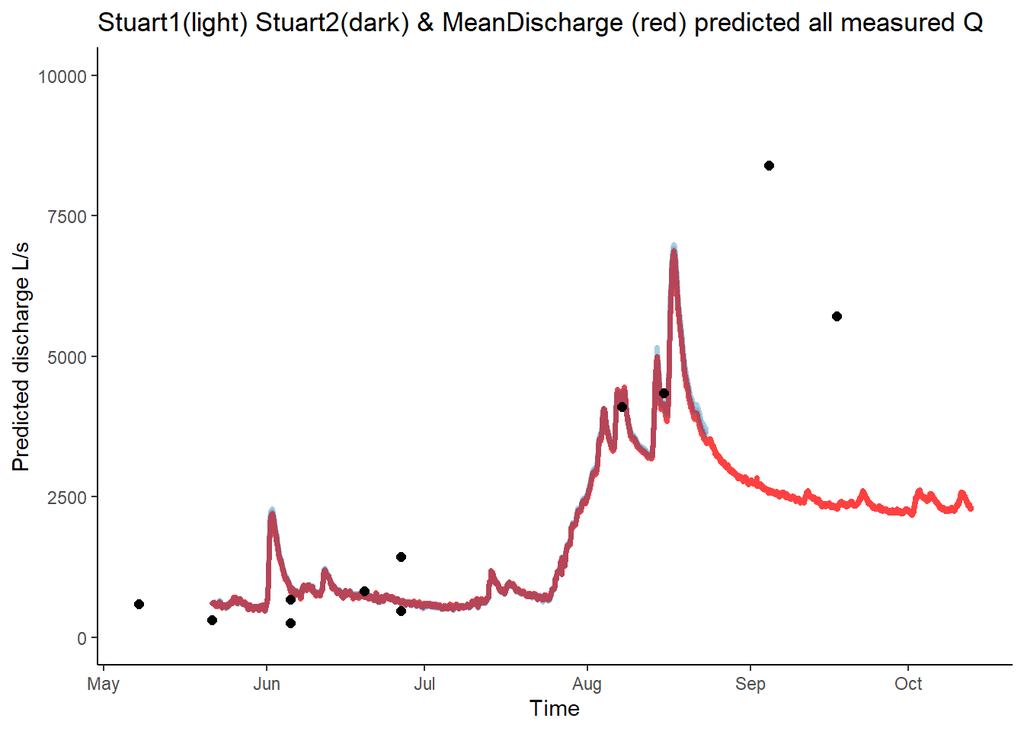

### export PT data to csv to DoD_Discharge->Predicted_Discharge->2019

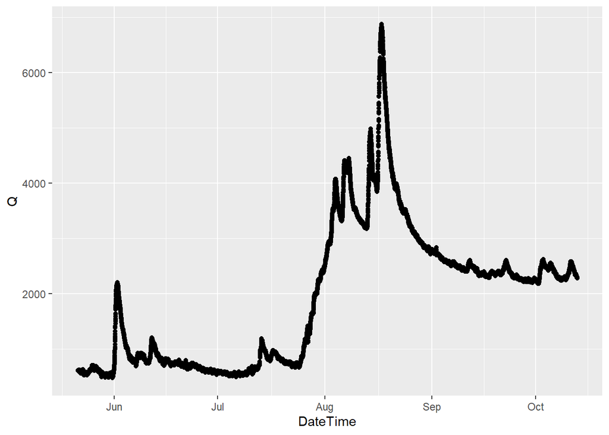

### export PT data to csv to DoD_Discharge->Predicted_Discharge->2019

```
## [1] 70612
```

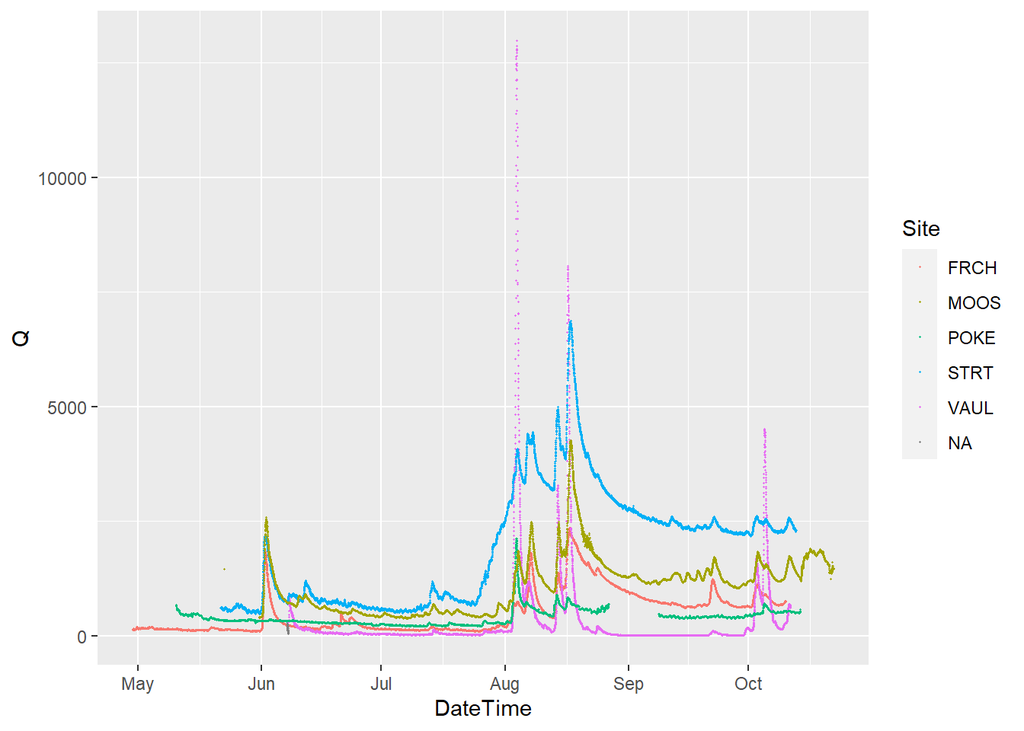